# Analysis of similarity matrix in experiments

Here, we are going to analyse the similarity matrix in experiments of quantum SLIM (SA and QPU) and classic SLIM elastic net. Regarding quantum SLIM, we are looking into the experiments with the following parameters: **{loss: NORM_MSE; aggregation: FIRST; top_k: 5}**

```python
import os, sys
import numpy as np
import matplotlib.pyplot as plt

sys.path.append("../")
```

```python
from src.utils.utilities import get_project_root_path
from course_lib.Data_manager.DataSplitter_k_fold import DataSplitter_Warm_k_fold
from src.data.NoHeaderCSVReader import NoHeaderCSVReader
from src.models.QuantumSLIM.QuantumSLIM_MSE import QuantumSLIM_MSE
from course_lib.Base.Evaluation.Evaluator import EvaluatorHoldout
from course_lib.SLIM_ElasticNet.SLIMElasticNetRecommender import SLIMElasticNetRecommender
```

```python
sa_folder = os.path.join(get_project_root_path(), "report", "quantum_slim", "Aug28_11-12-58")
qpu_folder = os.path.join(get_project_root_path(), "report", "quantum_slim", "Aug28_11-52-32")

dataset_filename = "small_ml100k.csv"
n_folds = 5
cutoff = 5
```

```python
# Here, we used the same split since we copied the file saved during the experiments

reader = NoHeaderCSVReader(filename=dataset_filename)
splitter = DataSplitter_Warm_k_fold(reader, n_folds=n_folds)
splitter.load_data()

URM_train, URM_val, URM_test = splitter.get_holdout_split()
URM_train
```

```
DataSplitter: Verifying data consistency...
DataSplitter: WARNING WARNING WARNING _verify_data_consistency not implemented for the current DataSplitter, unable to validate current split.
DataSplitter: Verifying data consistency... Passed!
DataSplitter_k_fold for DataReader: small_ml100k
	 Num items: 50
	 Num users: 174

	 Statistics for fold 0: n_interactions 213 ( 16.15%), n_items 50 ( 100.00%), density: 2.45E-02
	 Statistics for fold 1: n_interactions 261 ( 19.79%), n_items 50 ( 100.00%), density: 3.00E-02
	 Statistics for fold 2: n_interactions 261 ( 19.79%), n_items 50 ( 100.00%), density: 3.00E-02
	 Statistics for fold 3: n_interactions 261 ( 19.79%), n_items 50 ( 100.00%), density: 3.00E-02
	 Statistics for fold 4: n_interactions 323 ( 24.49%), n_items 50 ( 100.00%), density: 3.71E-02




DataSplitter: Done.
DataSplitter: Generating holdout split...
DataSplitter: Generating holdout split... done!
```

```
<174x50 sparse matrix of type '<class 'numpy.float64'>'
	with 845 stored elements in Compressed Sparse Row format>
```

## Analysis of the similarity matrix of SA

Regarding this analysis we can look into:

- the distribution of non-zero elements in each column (a column is an individual learned array from a qubo problem)
- a sort of comparison of the ratings of the non-zero elements in each column with the target ratings:
  - comparing the item popularity between them
  - ...

```python
sa_model = QuantumSLIM_MSE(URM_train, None)
sa_model.load_model(folder_path=sa_folder + "/")
```

```
QuantumSLIM_MSE: URM Detected 2 (4.00 %) cold items.
QuantumSLIM_MSE: Loading model from file '/Users/tangtang.zhou/Documents/GitHubProjects/qml-thesis-private/report/quantum_slim/Aug28_11-12-58/QuantumSLIM_MSE'
QuantumSLIM_MSE: Loading complete
```

```python
evaluator = EvaluatorHoldout(URM_val, cutoff_list=[cutoff])
results, _ = evaluator.evaluateRecommender(sa_model)
results
```

```
EvaluatorHoldout: Processed 174 ( 100.00% ) in 0.09 sec. Users per second: 1840
```

```
{5: {'ROC_AUC': 0.3218390804597701,
  'PRECISION': 0.13103448275862048,
  'PRECISION_RECALL_MIN_DEN': 0.4305555555555556,
  'RECALL': 0.4305555555555556,
  'MAP': 0.21858237547892728,
  'MRR': 0.30996168582375505,
  'NDCG': 0.29746634904937497,
  'F1': 0.2009210301893226,
  'HIT_RATE': 0.6551724137931034,
  'ARHR': 0.3323754789272033,
  'RMSE': 2.554480590977527,
  'NOVELTY': 0.4972533863408004,
  'AVERAGE_POPULARITY': 0.4341852603110211,
  'DIVERSITY_MEAN_INTER_LIST': 0.790924191083649,
  'DIVERSITY_HERFINDAHL': 0.9572757299511164,
  'COVERAGE_ITEM': 0.94,
  'COVERAGE_USER': 1.0,
  'DIVERSITY_GINI': 0.4686302681992337,
  'SHANNON_ENTROPY': 4.826310155519608}}
```

```python
s_matrix = sa_model.W_sparse
s_matrix
```

```
<50x50 sparse matrix of type '<class 'numpy.float64'>'
	with 231 stored elements in Compressed Sparse Row format>
```

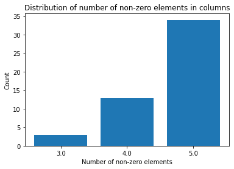

```python
n_top_elem = np.array(s_matrix.sum(axis=0)).flatten()
values, counts = np.unique(n_top_elem, return_counts=True)
plt.bar(values.astype("str"), counts)
plt.title("Distribution of number of non-zero elements in columns")
plt.xlabel("Number of non-zero elements")
plt.ylabel("Count")
plt.show()
```

Among 50 items, at least 34 of them has respected the applied constraint ("combinations") that select 5 variables among all 50. So, we have a 68% of problems in which the variables selected is the same as the one constrained.

### Comparison of selected items w.r.t. target item

Let's start with the comparison of item popularity.

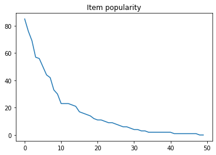

```python
item_pop = np.array((URM_train > 0).sum(axis=0)).flatten()
item_pop = np.sort(item_pop)[::-1]
plt.plot(item_pop)
plt.title("Item popularity")
plt.show()
```

```
The item 0 with 50 popularity has these similar items popularity [85 17 23  0]
The item 1 with 76 popularity has these similar items popularity [44 69 33]
The item 2 with 85 popularity has these similar items popularity [21 69 56]
The item 3 with 21 popularity has these similar items popularity [30  9  6  2]
The item 4 with 42 popularity has these similar items popularity [85 15  3  1]
The item 5 with 44 popularity has these similar items popularity [76  7 23 33]
The item 6 with 5 popularity has these similar items popularity [ 2  9 12  6  1]
The item 7 with 7 popularity has these similar items popularity [5 2 1 4 1]
The item 8 with 10 popularity has these similar items popularity [ 5 12  1  8  1]
The item 9 with 23 popularity has these similar items popularity [23 33  6  1]
The item 10 with 17 popularity has these similar items popularity [50  5  1  8  1]
The item 11 with 69 popularity has these similar items popularity [76 85  4]
The item 12 with 23 popularity has these similar items popularity [23 22 12  1]
The item 13 with 14 popularity has these similar items popularity [ 9 23  2  1  2]
The item 14 with 22 popularity has these similar items popularity [23 30 33  4]
The item 15 with 57 popularity has these similar items popularity [50 21 56 23]
The item 16 with 2 popularity has these similar items popularity [1 1 1 1 2]
The item 17 with 16 popularity has these similar items popularity [ 2 33 11  3  6]
The item 18 with 15 popularity has these similar items popularity [42 11  1  0]
The item 19 with 30 popularity has these similar items popularity [21 10 22  1]
The item 20 with 9 popularity has these similar items popularity [21 14  2  0  1]
The item 21 with 56 popularity has these similar items popularity [85 10 57  4]
The item 22 with 9 popularity has these similar items popularity [ 5 11 11  3 12]
The item 23 with 33 popularity has these similar items popularity [76 23 22  2]
The item 24 with 11 popularity has these similar items popularity [16  9  1  6  2]
The item 25 with 4 popularity has these similar items popularity [10  2  1  8  2]
The item 26 with 23 popularity has these similar items popularity [14 57  4  4]
The item 27 with 11 popularity has these similar items popularity [14  9  1  8  2]
The item 28 with 6 popularity has these similar items popularity [14  2 12  1  2]
The item 29 with 3 popularity has these similar items popularity [3 1 1 1 1]
The item 30 with 2 popularity has these similar items popularity [2 1 2 1 1]
The item 31 with 0 popularity has these similar items popularity [2 1 1 1 2]
The item 32 with 12 popularity has these similar items popularity [5 9 2 1 2]
The item 33 with 3 popularity has these similar items popularity [ 0 12  2  1  0]
The item 34 with 1 popularity has these similar items popularity [2 3 2 0 0]
The item 35 with 2 popularity has these similar items popularity [1 2 4 2 0]
The item 36 with 6 popularity has these similar items popularity [ 5 16  1  1  0]
The item 37 with 2 popularity has these similar items popularity [12  3  1  1  1]
The item 38 with 1 popularity has these similar items popularity [0 1 2 1 2]
The item 39 with 1 popularity has these similar items popularity [2 1 4 1 2]
The item 40 with 2 popularity has these similar items popularity [3 1 1 1 0]
The item 41 with 1 popularity has these similar items popularity [3 0 1 1 2]
The item 42 with 8 popularity has these similar items popularity [ 4 23  2  1  1]
The item 43 with 4 popularity has these similar items popularity [2 1 1 2 0]
The item 44 with 1 popularity has these similar items popularity [2 1 1 4 2]
The item 45 with 1 popularity has these similar items popularity [7 2 2 1 2]
The item 46 with 1 popularity has these similar items popularity [2 0 2 1 1]
The item 47 with 2 popularity has these similar items popularity [2 0 1 1 1]
The item 48 with 2 popularity has these similar items popularity [2 0 2 4 1]
The item 49 with 0 popularity has these similar items popularity [0 1 1 1 1]
```

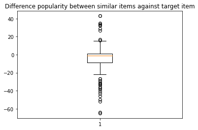

```python
item_pop = np.array((URM_train > 0).sum(axis=0)).flatten()
diff_pop = []
sim_item_count = np.zeros(shape=s_matrix.shape[0])

for curr_item in range(s_matrix.shape[0]):
    s_column = s_matrix[:, curr_item].toarray().flatten()
    sim_item_count += s_column

    sim_pop = item_pop[np.array(s_column, dtype=bool)]
    target_pop = item_pop[curr_item]

    print("The item {} with {} popularity has these similar items popularity {}".format(curr_item, target_pop, sim_pop))

    diff_pop.extend((sim_pop - target_pop))
plt.boxplot(diff_pop)
plt.title("Difference popularity between similar items against target item")
plt.show()
```

Looking at all these item popularity of the similar items found by SA, we can see that it tends to find items that has similar popularity because the NORM_MSE loss is a loss that takes into account all ratings (also zero ratings). Indeed, the number of very popular items inside the similar items are quite low; only those with high popularity has popular items as similar items.

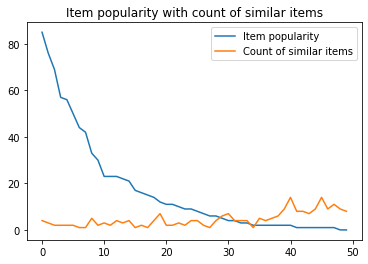

```python
item_pop = np.array((URM_train > 0).sum(axis=0)).flatten()
sort_indices = np.argsort(item_pop)[::-1]
item_pop = item_pop[sort_indices]
plt.plot(item_pop, label="Item popularity")
plt.plot(sim_item_count[sort_indices], label="Count of similar items")
plt.title("Item popularity with count of similar items")
plt.legend()
plt.show()
```

In this plot, we can see that the similar items are more the one unpopular since there are more unpopular items than popular ones.

## Analysis of similarity matrix of QPU

```python
qpu_model = QuantumSLIM_MSE(URM_train, None)
qpu_model.load_model(folder_path=qpu_folder + "/")
```

```
QuantumSLIM_MSE: URM Detected 2 (4.00 %) cold items.
QuantumSLIM_MSE: Loading model from file '/Users/tangtang.zhou/Documents/GitHubProjects/qml-thesis-private/report/quantum_slim/Aug28_11-52-32/QuantumSLIM_MSE'
QuantumSLIM_MSE: Loading complete
```

```python
evaluator = EvaluatorHoldout(URM_val, cutoff_list=[cutoff])
results, _ = evaluator.evaluateRecommender(qpu_model)
results
```

```
EvaluatorHoldout: Processed 174 ( 100.00% ) in 0.06 sec. Users per second: 3031
```

```
{5: {'ROC_AUC': 0.12452107279693485,
  'PRECISION': 0.05517241379310347,
  'PRECISION_RECALL_MIN_DEN': 0.17097701149425287,
  'RECALL': 0.17097701149425287,
  'MAP': 0.08933588761174967,
  'MRR': 0.121551724137931,
  'NDCG': 0.11175588905361705,
  'F1': 0.08342461551943217,
  'HIT_RATE': 0.27586206896551724,
  'ARHR': 0.13275862068965513,
  'RMSE': 2.881972401999542,
  'NOVELTY': 0.6269060995774541,
  'AVERAGE_POPULARITY': 0.2007437457741717,
  'DIVERSITY_MEAN_INTER_LIST': 0.8297255996279318,
  'DIVERSITY_HERFINDAHL': 0.9649914123398071,
  'COVERAGE_ITEM': 1.0,
  'COVERAGE_USER': 1.0,
  'DIVERSITY_GINI': 0.538517016001803,
  'SHANNON_ENTROPY': 5.1157365491486395}}
```

```python
s_matrix = qpu_model.W_sparse
s_matrix
```

```
<50x50 sparse matrix of type '<class 'numpy.float64'>'
	with 240 stored elements in Compressed Sparse Row format>
```

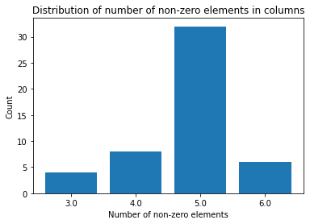

```python
n_top_elem = np.array(s_matrix.sum(axis=0)).flatten()
values, counts = np.unique(n_top_elem, return_counts=True)
plt.bar(values.astype("str"), counts)
plt.title("Distribution of number of non-zero elements in columns")
plt.xlabel("Number of non-zero elements")
plt.ylabel("Count")
plt.show()
```

Also, in QPU, there is a distribution similar to the one of SA, but, here we have also samples with 6 non-zero elements.

### Comparison of selected items w.r.t. target item

```
The item 0 with 50 popularity has these similar items popularity [14 16 30 56  6]
The item 1 with 76 popularity has these similar items popularity [42 23  2]
The item 2 with 85 popularity has these similar items popularity [23 14  2]
The item 3 with 21 popularity has these similar items popularity [23 57  9  3  1]
The item 4 with 42 popularity has these similar items popularity [85 12  6  2]
The item 5 with 44 popularity has these similar items popularity [50 76 14 56]
The item 6 with 5 popularity has these similar items popularity [15  2  6  4  1]
The item 7 with 7 popularity has these similar items popularity [42  5  9  2  1]
The item 8 with 10 popularity has these similar items popularity [7 3 0 3 2]
The item 9 with 23 popularity has these similar items popularity [3 4 1 2]
The item 10 with 17 popularity has these similar items popularity [2 6 1 4 1]
The item 11 with 69 popularity has these similar items popularity [57 11  8]
The item 12 with 23 popularity has these similar items popularity [42  5  7 22]
The item 13 with 14 popularity has these similar items popularity [ 7 22  6  1  1]
The item 14 with 22 popularity has these similar items popularity [ 5  7 17  3  1]
The item 15 with 57 popularity has these similar items popularity [ 9 56  2  2]
The item 16 with 2 popularity has these similar items popularity [21  9  2  2  2]
The item 17 with 16 popularity has these similar items popularity [42  7 23  6  6]
The item 18 with 15 popularity has these similar items popularity [ 7 14 11  3  1]
The item 19 with 30 popularity has these similar items popularity [21 23 17  0]
The item 20 with 9 popularity has these similar items popularity [85 21  1  2  2]
The item 21 with 56 popularity has these similar items popularity [50 22  9]
The item 22 with 9 popularity has these similar items popularity [ 7 30 11  3  1]
The item 23 with 33 popularity has these similar items popularity [44 16 15  3]
The item 24 with 11 popularity has these similar items popularity [42  5 11  1  6]
The item 25 with 4 popularity has these similar items popularity [2 1 8 4 2]
The item 26 with 23 popularity has these similar items popularity [5 2 4 1]
The item 27 with 11 popularity has these similar items popularity [9 6 3 2 1 1]
The item 28 with 6 popularity has these similar items popularity [21 44  4  1  1]
The item 29 with 3 popularity has these similar items popularity [11  1  2  2  0]
The item 30 with 2 popularity has these similar items popularity [6 3 1 1 8]
The item 31 with 0 popularity has these similar items popularity [44 23  2  1  1  2]
The item 32 with 12 popularity has these similar items popularity [23  1  2  1  1]
The item 33 with 3 popularity has these similar items popularity [ 7 69  9  6  1]
The item 34 with 1 popularity has these similar items popularity [50 44  6  3  2]
The item 35 with 2 popularity has these similar items popularity [10  3  3  6  1]
The item 36 with 6 popularity has these similar items popularity [ 5 69  4  2  1]
The item 37 with 2 popularity has these similar items popularity [ 5 30  1  1  0]
The item 38 with 1 popularity has these similar items popularity [44 23 15 11  2  1]
The item 39 with 1 popularity has these similar items popularity [22 11  0  3  8]
The item 40 with 2 popularity has these similar items popularity [50 14 30 33  3  1]
The item 41 with 1 popularity has these similar items popularity [50 33  3  1  8]
The item 42 with 8 popularity has these similar items popularity [50  7  9 12  1]
The item 43 with 4 popularity has these similar items popularity [30  0  3  1  2]
The item 44 with 1 popularity has these similar items popularity [10 11  3  1  2  2]
The item 45 with 1 popularity has these similar items popularity [21  4 12  3  8  1]
The item 46 with 1 popularity has these similar items popularity [ 7 30  4  2  1]
The item 47 with 2 popularity has these similar items popularity [9 3 6 1 1]
The item 48 with 2 popularity has these similar items popularity [33  3  4  1  0]
The item 49 with 0 popularity has these similar items popularity [44 15 30  1  1]
```

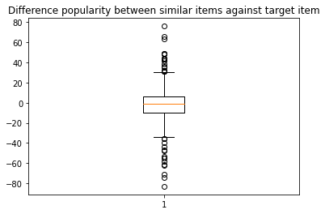

```python
item_pop = np.array((URM_train > 0).sum(axis=0)).flatten()
diff_pop = []
sim_item_count = np.zeros(shape=s_matrix.shape[0])

for curr_item in range(s_matrix.shape[0]):
    s_column = s_matrix[:, curr_item].toarray().flatten()
    sim_item_count += s_column

    sim_pop = item_pop[np.array(s_column, dtype=bool)]
    target_pop = item_pop[curr_item]

    print("The item {} with {} popularity has these similar items popularity {}".format(curr_item, target_pop, sim_pop))

    diff_pop.extend((sim_pop - target_pop))
plt.boxplot(diff_pop)
plt.title("Difference popularity between similar items against target item")
plt.show()
```

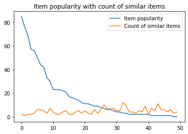

```python
item_pop = np.array((URM_train > 0).sum(axis=0)).flatten()
sort_indices = np.argsort(item_pop)[::-1]
item_pop = item_pop[sort_indices]
plt.plot(item_pop, label="Item popularity")
plt.plot(sim_item_count[sort_indices], label="Count of similar items")
plt.title("Item popularity with count of similar items")
plt.legend()
plt.show()
```

Looking at these graphs, the behavior is still very similar to the SA case, but in this case we can see that low popular items can also get high popular items as similar items.

## Analysis of similarity matrix of SLIM Elastic Net

```python
slim_model = SLIMElasticNetRecommender(URM_train)
slim_model.fit(topK=5)
```

```
SLIMElasticNetRecommender: URM Detected 2 (4.00 %) cold items.
SLIMElasticNetRecommender: Processed 50 ( 100.00% ) in 0.13 sec. Items per second: 372.78
```

```python
evaluator = EvaluatorHoldout(URM_val, cutoff_list=[cutoff])
results, _ = evaluator.evaluateRecommender(slim_model)
results
```

```
EvaluatorHoldout: Processed 174 ( 100.00% ) in 0.16 sec. Users per second: 1110
```

```
{5: {'ROC_AUC': 0.39272030651341,
  'PRECISION': 0.15172413793103423,
  'PRECISION_RECALL_MIN_DEN': 0.5172413793103449,
  'RECALL': 0.5172413793103449,
  'MAP': 0.29393358876117504,
  'MRR': 0.37260536398467453,
  'NDCG': 0.3732485354546158,
  'F1': 0.2346249555634551,
  'HIT_RATE': 0.7586206896551724,
  'ARHR': 0.4121647509578546,
  'RMSE': 2.9800197492619276,
  'NOVELTY': 0.4375244389095606,
  'AVERAGE_POPULARITY': 0.5501284651791752,
  'DIVERSITY_MEAN_INTER_LIST': 0.6731247093216398,
  'DIVERSITY_HERFINDAHL': 0.9338512353018893,
  'COVERAGE_ITEM': 0.6,
  'COVERAGE_USER': 1.0,
  'DIVERSITY_GINI': 0.47296996662958846,
  'SHANNON_ENTROPY': 4.105889344108344}}
```

```python
s_matrix = slim_model.W_sparse
s_matrix
```

```
<50x50 sparse matrix of type '<class 'numpy.float32'>'
	with 137 stored elements in Compressed Sparse Row format>
```

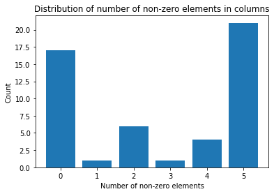

```python
n_top_elem = np.array((s_matrix > 0).sum(axis=0)).flatten()
values, counts = np.unique(n_top_elem, return_counts=True)

plt.bar(values.astype("str"), counts)
plt.title("Distribution of number of non-zero elements in columns")
plt.xlabel("Number of non-zero elements")
plt.ylabel("Count")
plt.show()
```

In this case, the distribution of non-zero values are scattered also on 0, 1 and 2. And there is only half of the columns with 5 non-zero elements.

### Comparison of selected items w.r.t. target item

```
The item 0 with 50 popularity has these similar items with popularity: [85 17 57 56 23]
The item 1 with 76 popularity has these similar items with popularity: [44 69 23 57 33]
The item 2 with 85 popularity has these similar items with popularity: [50 21 42 69 56]
The item 3 with 21 popularity has these similar items with popularity: [50 85 57 30  9]
The item 4 with 42 popularity has these similar items with popularity: [85 69 16 15 30]
The item 5 with 44 popularity has these similar items with popularity: [76 69 23 30 33]
The item 6 with 5 popularity has these similar items with popularity: [85  9 12  6]
The item 7 with 7 popularity has these similar items with popularity: [85 44]
The item 8 with 10 popularity has these similar items with popularity: [76 44 56 33]
The item 9 with 23 popularity has these similar items with popularity: [85 23 22 33  6]
The item 10 with 17 popularity has these similar items with popularity: [50 85 15]
The item 11 with 69 popularity has these similar items with popularity: [76 85 57 56  4]
The item 12 with 23 popularity has these similar items with popularity: [76 44 23 22 12]
The item 13 with 14 popularity has these similar items with popularity: [50 85 15 56 23]
The item 14 with 22 popularity has these similar items with popularity: [23 69 23 30 33]
The item 15 with 57 popularity has these similar items with popularity: [50 76 69 56 23]
The item 16 with 2 popularity has these similar items with popularity: []
The item 17 with 16 popularity has these similar items with popularity: [50 85 42 33 11]
The item 18 with 15 popularity has these similar items with popularity: [76 42 17 22 11]
The item 19 with 30 popularity has these similar items with popularity: [85 21 42 44 22]
The item 20 with 9 popularity has these similar items with popularity: [21 69]
The item 21 with 56 popularity has these similar items with popularity: [50 85 10 69 57]
The item 22 with 9 popularity has these similar items with popularity: [85  5 23 57 12]
The item 23 with 33 popularity has these similar items with popularity: [76 44 23 22 16]
The item 24 with 11 popularity has these similar items with popularity: [76 85 42 69 16]
The item 25 with 4 popularity has these similar items with popularity: [69]
The item 26 with 23 popularity has these similar items with popularity: [50 76 69 14 57]
The item 27 with 11 popularity has these similar items with popularity: [85 57]
The item 28 with 6 popularity has these similar items with popularity: [50 85 57 23]
The item 29 with 3 popularity has these similar items with popularity: []
The item 30 with 2 popularity has these similar items with popularity: []
The item 31 with 0 popularity has these similar items with popularity: []
The item 32 with 12 popularity has these similar items with popularity: [85 42 23  9  2]
The item 33 with 3 popularity has these similar items with popularity: [85  2]
The item 34 with 1 popularity has these similar items with popularity: []
The item 35 with 2 popularity has these similar items with popularity: []
The item 36 with 6 popularity has these similar items with popularity: [85 23]
The item 37 with 2 popularity has these similar items with popularity: [42  3]
The item 38 with 1 popularity has these similar items with popularity: []
The item 39 with 1 popularity has these similar items with popularity: []
The item 40 with 2 popularity has these similar items with popularity: []
The item 41 with 1 popularity has these similar items with popularity: []
The item 42 with 8 popularity has these similar items with popularity: [76 69 56 23]
The item 43 with 4 popularity has these similar items with popularity: []
The item 44 with 1 popularity has these similar items with popularity: []
The item 45 with 1 popularity has these similar items with popularity: []
The item 46 with 1 popularity has these similar items with popularity: []
The item 47 with 2 popularity has these similar items with popularity: []
The item 48 with 2 popularity has these similar items with popularity: []
The item 49 with 0 popularity has these similar items with popularity: []
```

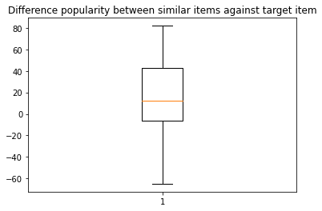

```python
item_pop = np.array((URM_train > 0).sum(axis=0)).flatten()
diff_pop = []
sim_item_count = np.zeros(shape=s_matrix.shape[0])

for curr_item in range(s_matrix.shape[0]):
    s_column = (s_matrix[:, curr_item] > 0).toarray().flatten()
    sim_item_count += s_column

    sim_pop = item_pop[np.array(s_column, dtype=bool)]
    target_pop = item_pop[curr_item]

    print("The item {} with {} popularity has these similar items with popularity: {}".format(curr_item, target_pop, sim_pop))

    diff_pop.extend((sim_pop - target_pop))
plt.boxplot(diff_pop)
plt.title("Difference popularity between similar items against target item")
plt.show()
```

From this information and plot, we can see that the difference popularity is not centered in the 0, but above. Indeed, in the list of information above the box plot, there are a lot of similar items that are highly popular (remember that the most popular item is the one with 85 popularity); and here, items, that are not so popular, have popular items as similar items.

Moreover, there are a lot of low popular items that has no similar items.

Clearly, this happens because SLIM Elastic Net has been trained only on positive ratings.

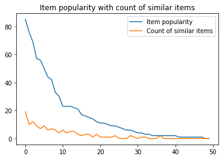

```python
item_pop = np.array((URM_train > 0).sum(axis=0)).flatten()
sort_indices = np.argsort(item_pop)[::-1]
item_pop = item_pop[sort_indices]
plt.plot(item_pop, label="Item popularity")
plt.plot(sim_item_count[sort_indices], label="Count of similar items")
plt.title("Item popularity with count of similar items")
plt.legend()
plt.show()
```

Here, the similar items are, clearly, more on the popular side.

## EXTRA: Non-zero norm-MSE loss of SA experiment

```python
sa_folder = os.path.join(get_project_root_path(), "report", "quantum_slim", "Aug31_10-28-07")
```

```python
sa_model = QuantumSLIM_MSE(URM_train, None)
sa_model.load_model(folder_path=sa_folder + "/")
```

```
QuantumSLIM_MSE: URM Detected 2 (4.00 %) cold items.
QuantumSLIM_MSE: Loading model from file '/Users/tangtang.zhou/Documents/GitHubProjects/qml-thesis-private/report/quantum_slim/Aug31_10-28-07/QuantumSLIM_MSE'
QuantumSLIM_MSE: Loading complete
```

```python
evaluator = EvaluatorHoldout(URM_val, cutoff_list=[cutoff])
results, _ = evaluator.evaluateRecommender(sa_model)
results
```

```
EvaluatorHoldout: Processed 174 ( 100.00% ) in 0.06 sec. Users per second: 2863
```

```
{5: {'ROC_AUC': 0.16379310344827586,
  'PRECISION': 0.06321839080459767,
  'PRECISION_RECALL_MIN_DEN': 0.20977011494252873,
  'RECALL': 0.20977011494252873,
  'MAP': 0.11944444444444445,
  'MRR': 0.16091954022988503,
  'NDCG': 0.1504601277625081,
  'F1': 0.09715668481548695,
  'HIT_RATE': 0.3160919540229885,
  'ARHR': 0.17116858237547888,
  'RMSE': 3.353534680096757,
  'NOVELTY': 0.6360901039613742,
  'AVERAGE_POPULARITY': 0.2169574036511157,
  'DIVERSITY_MEAN_INTER_LIST': 0.8709720284366488,
  'DIVERSITY_HERFINDAHL': 0.9731932884132646,
  'COVERAGE_ITEM': 1.0,
  'COVERAGE_USER': 1.0,
  'DIVERSITY_GINI': 0.6767185034933514,
  'SHANNON_ENTROPY': 5.38904343428613}}
```

```python
s_matrix = sa_model.W_sparse
s_matrix
```

```
<50x50 sparse matrix of type '<class 'numpy.float64'>'
	with 207 stored elements in Compressed Sparse Row format>
```

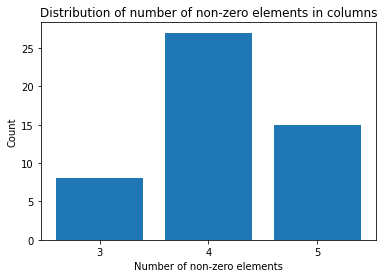

```python
n_top_elem = np.array((s_matrix > 0).sum(axis=0)).flatten()
values, counts = np.unique(n_top_elem, return_counts=True)
plt.bar(values.astype("str"), counts)
plt.title("Distribution of number of non-zero elements in columns")
plt.xlabel("Number of non-zero elements")
plt.ylabel("Count")
plt.show()
```

In this case, the distribution is more concentrated on 4 non-zero elements.

### Comparison of selected items w.r.t. target item

```
The item 0 with 50 popularity has these similar items popularity [85 69 57 56]
The item 1 with 76 popularity has these similar items popularity [85 44 69]
The item 2 with 85 popularity has these similar items popularity [76 69 56]
The item 3 with 21 popularity has these similar items popularity [50 85 57 30]
The item 4 with 42 popularity has these similar items popularity [76 85 69 15]
The item 5 with 44 popularity has these similar items popularity [76 85 69]
The item 6 with 5 popularity has these similar items popularity [85 57  9  6]
The item 7 with 7 popularity has these similar items popularity [76 85 44  1]
The item 8 with 10 popularity has these similar items popularity [76 85 44 56]
The item 9 with 23 popularity has these similar items popularity [85 69 33]
The item 10 with 17 popularity has these similar items popularity [50 85 69 15]
The item 11 with 69 popularity has these similar items popularity [76 85 56]
The item 12 with 23 popularity has these similar items popularity [76 85 23 69]
The item 13 with 14 popularity has these similar items popularity [76 85 44 23]
The item 14 with 22 popularity has these similar items popularity [76 23 33]
The item 15 with 57 popularity has these similar items popularity [76 85 69 56]
The item 16 with 2 popularity has these similar items popularity [76 11  4  1  2]
The item 17 with 16 popularity has these similar items popularity [85 42 69 33]
The item 18 with 15 popularity has these similar items popularity [76 42 69]
The item 19 with 30 popularity has these similar items popularity [85 44 56]
The item 20 with 9 popularity has these similar items popularity [76 21 69 30]
The item 21 with 56 popularity has these similar items popularity [76 85 69 57]
The item 22 with 9 popularity has these similar items popularity [85 69 56 12]
The item 23 with 33 popularity has these similar items popularity [76 85 44 22]
The item 24 with 11 popularity has these similar items popularity [76 85 69 16]
The item 25 with 4 popularity has these similar items popularity [85 69 56  9]
The item 26 with 23 popularity has these similar items popularity [76 85 69 57]
The item 27 with 11 popularity has these similar items popularity [85 42 57 15]
The item 28 with 6 popularity has these similar items popularity [50 85 21 57]
The item 29 with 3 popularity has these similar items popularity [76 85 15  2  1]
The item 30 with 2 popularity has these similar items popularity [23 69 33  3  1]
The item 31 with 0 popularity has these similar items popularity [10 30  3  1  6]
The item 32 with 12 popularity has these similar items popularity [85 42 23  9]
The item 33 with 3 popularity has these similar items popularity [85 22 30 12  2]
The item 34 with 1 popularity has these similar items popularity [76 69 23 22 11]
The item 35 with 2 popularity has these similar items popularity [85 23 69 30]
The item 36 with 6 popularity has these similar items popularity [85  5 23 17]
The item 37 with 2 popularity has these similar items popularity [85 42  3  1]
The item 38 with 1 popularity has these similar items popularity [17 23 16  9  4]
The item 39 with 1 popularity has these similar items popularity [50 17 57  9  4]
The item 40 with 2 popularity has these similar items popularity [ 7 57 15 56  1]
The item 41 with 1 popularity has these similar items popularity [ 7 15  3  2]
The item 42 with 8 popularity has these similar items popularity [76 69 57 56]
The item 43 with 4 popularity has these similar items popularity [50 22 56  1  1]
The item 44 with 1 popularity has these similar items popularity [17 69 16  9  2]
The item 45 with 1 popularity has these similar items popularity [ 7 23 22 33  2]
The item 46 with 1 popularity has these similar items popularity [23 69 22 57  8]
The item 47 with 2 popularity has these similar items popularity [17  2 11 11]
The item 48 with 2 popularity has these similar items popularity [76 85 23  3  6]
The item 49 with 0 popularity has these similar items popularity [69  2 56 12  2]
```

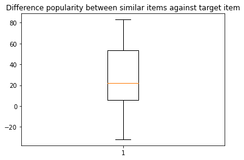

```python
item_pop = np.array((URM_train > 0).sum(axis=0)).flatten()
diff_pop = []
sim_item_count = np.zeros(shape=s_matrix.shape[0])

for curr_item in range(s_matrix.shape[0]):
    s_column = s_matrix[:, curr_item].toarray().flatten()
    sim_item_count += s_column

    sim_pop = item_pop[np.array(s_column, dtype=bool)]
    target_pop = item_pop[curr_item]

    print("The item {} with {} popularity has these similar items popularity {}".format(curr_item, target_pop, sim_pop))

    diff_pop.extend((sim_pop - target_pop))
plt.boxplot(diff_pop)
plt.title("Difference popularity between similar items against target item")
plt.show()
```

This distribution seems very similar to the SLIM Elastic Net, but here, the items with low popularity has similar items. Of course, the item with 0 ratings has random similar items, and maybe also the one with 1 ratings.

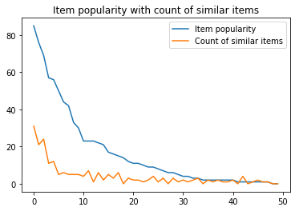

```python
item_pop = np.array((URM_train > 0).sum(axis=0)).flatten()
sort_indices = np.argsort(item_pop)[::-1]
item_pop = item_pop[sort_indices]
plt.plot(item_pop, label="Item popularity")
plt.plot(sim_item_count[sort_indices], label="Count of similar items")
plt.title("Item popularity with count of similar items")
plt.legend()
plt.show()
```

Indeed, the count of similar items is all about popular items just like SLIM Elastic Net.

### Elimination of the similarity of low popular items

Let's see what happens if we try to eliminate the similarity of low popular items (e.g. items with less or equal than 3 popularity)

```python
item_pop = np.array((URM_train > 0).sum(axis=0)).flatten()
s_matrix = sa_model.W_sparse
s_matrix[:, item_pop <= 3] = 0
```

```python
s_matrix.eliminate_zeros()
s_matrix
```

```
<50x50 sparse matrix of type '<class 'numpy.float64'>'
	with 121 stored elements in Compressed Sparse Row format>
```

```
The item 0 with 50 popularity has these similar items popularity [85 69 57 56]
The item 1 with 76 popularity has these similar items popularity [85 44 69]
The item 2 with 85 popularity has these similar items popularity [76 69 56]
The item 3 with 21 popularity has these similar items popularity [50 85 57 30]
The item 4 with 42 popularity has these similar items popularity [76 85 69 15]
The item 5 with 44 popularity has these similar items popularity [76 85 69]
The item 6 with 5 popularity has these similar items popularity [85 57  9  6]
The item 7 with 7 popularity has these similar items popularity [76 85 44  1]
The item 8 with 10 popularity has these similar items popularity [76 85 44 56]
The item 9 with 23 popularity has these similar items popularity [85 69 33]
The item 10 with 17 popularity has these similar items popularity [50 85 69 15]
The item 11 with 69 popularity has these similar items popularity [76 85 56]
The item 12 with 23 popularity has these similar items popularity [76 85 23 69]
The item 13 with 14 popularity has these similar items popularity [76 85 44 23]
The item 14 with 22 popularity has these similar items popularity [76 23 33]
The item 15 with 57 popularity has these similar items popularity [76 85 69 56]
The item 16 with 2 popularity has these similar items popularity []
The item 17 with 16 popularity has these similar items popularity [85 42 69 33]
The item 18 with 15 popularity has these similar items popularity [76 42 69]
The item 19 with 30 popularity has these similar items popularity [85 44 56]
The item 20 with 9 popularity has these similar items popularity [76 21 69 30]
The item 21 with 56 popularity has these similar items popularity [76 85 69 57]
The item 22 with 9 popularity has these similar items popularity [85 69 56 12]
The item 23 with 33 popularity has these similar items popularity [76 85 44 22]
The item 24 with 11 popularity has these similar items popularity [76 85 69 16]
The item 25 with 4 popularity has these similar items popularity [85 69 56  9]
The item 26 with 23 popularity has these similar items popularity [76 85 69 57]
The item 27 with 11 popularity has these similar items popularity [85 42 57 15]
The item 28 with 6 popularity has these similar items popularity [50 85 21 57]
The item 29 with 3 popularity has these similar items popularity []
The item 30 with 2 popularity has these similar items popularity []
The item 31 with 0 popularity has these similar items popularity []
The item 32 with 12 popularity has these similar items popularity [85 42 23  9]
The item 33 with 3 popularity has these similar items popularity []
The item 34 with 1 popularity has these similar items popularity []
The item 35 with 2 popularity has these similar items popularity []
The item 36 with 6 popularity has these similar items popularity [85  5 23 17]
The item 37 with 2 popularity has these similar items popularity []
The item 38 with 1 popularity has these similar items popularity []
The item 39 with 1 popularity has these similar items popularity []
The item 40 with 2 popularity has these similar items popularity []
The item 41 with 1 popularity has these similar items popularity []
The item 42 with 8 popularity has these similar items popularity [76 69 57 56]
The item 43 with 4 popularity has these similar items popularity [50 22 56  1  1]
The item 44 with 1 popularity has these similar items popularity []
The item 45 with 1 popularity has these similar items popularity []
The item 46 with 1 popularity has these similar items popularity []
The item 47 with 2 popularity has these similar items popularity []
The item 48 with 2 popularity has these similar items popularity []
The item 49 with 0 popularity has these similar items popularity []
```

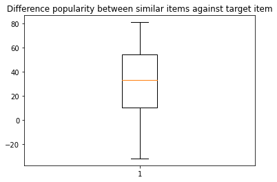

```python
diff_pop = []
sim_item_count = np.zeros(shape=s_matrix.shape[0])

for curr_item in range(s_matrix.shape[0]):
    s_column = s_matrix[:, curr_item].toarray().flatten()
    sim_item_count += s_column

    sim_pop = item_pop[np.array(s_column, dtype=bool)]
    target_pop = item_pop[curr_item]

    print("The item {} with {} popularity has these similar items popularity {}".format(curr_item, target_pop, sim_pop))

    diff_pop.extend((sim_pop - target_pop))
plt.boxplot(diff_pop)
plt.title("Difference popularity between similar items against target item")
plt.show()
```

```python
sa_model.W_sparse = s_matrix
evaluator = EvaluatorHoldout(URM_val, cutoff_list=[cutoff])
results, _ = evaluator.evaluateRecommender(sa_model)
results
```

```
EvaluatorHoldout: Processed 174 ( 100.00% ) in 0.06 sec. Users per second: 3024
```

```
{5: {'ROC_AUC': 0.19540229885057472,
  'PRECISION': 0.07931034482758612,
  'PRECISION_RECALL_MIN_DEN': 0.27155172413793105,
  'RECALL': 0.27155172413793105,
  'MAP': 0.13596743295019156,
  'MRR': 0.1867816091954022,
  'NDCG': 0.17974332565891332,
  'F1': 0.12276539862746748,
  'HIT_RATE': 0.39655172413793105,
  'ARHR': 0.19798850574712643,
  'RMSE': 3.3611368549818614,
  'NOVELTY': 0.5688712946345283,
  'AVERAGE_POPULARITY': 0.2774036511156187,
  'DIVERSITY_MEAN_INTER_LIST': 0.8255531193940602,
  'DIVERSITY_HERFINDAHL': 0.9641617122473246,
  'COVERAGE_ITEM': 0.76,
  'COVERAGE_USER': 1.0,
  'DIVERSITY_GINI': 0.6651340996168584,
  'SHANNON_ENTROPY': 4.9429672546458825}}
```

The MAP did increase, but there is not much improvement.